# 間接質問法 第2回

推定・グラフの作成・レポートの書き方

福島 健太郎(行動統計科学)

## この資料は

- htmlで作成しています。
  - (Quarto&revealjsを用いています。)
- PDF化できますが、表示が崩れる可能性が高いです。
- ブラウザからhtmlで見ることをお勧めします。
- https://fukushima-k.github.io/IndirectQuestionPublish/slide2_trialから最新版を閲覧できます。

## 授業の流れ

- 第１回 (6/22 or 7/13)
  - 教員自己紹介
  - 実験(調査) 質問フォームへの回答
  - 講義：間接質問法
  - 今回の研究とそのポイント
- **第２回 (6/29 or 7/27)**
  - データの分析・説明
    - Rを使います
  - レポートの書き方

## 今日やること

- 前回の復習
- データの確認
- 理解度確認と分析対象者の決定
- クロスワイズモデルによる推定
- グラフの作成
- レポートの書き方

# 前回の復習

## 前回の復習：センシティブ項目

センシティブ項目とは、回答者が答えるのをためらいやすい質問である。

- 正直に答えることが難しい
- 無回答や虚偽回答が生じやすい
- 社会的に望ましくない行動では過少報告が起こりうる

観測された回答が、そのまま実態を表すとは限らない。

## 前回の復習：クロスワイズモデル (Yu ほか, 2008)

以下の2つの質問について考えてください。

- あなたは、過去にカンニング行為をしたことがありますか？
- あなたは、5月生まれですか？

以下のどちらかのみを選択してください。

A. 2つの質問に対する答えが**同じ** (YES&YES or NO&NO)

B. 2つの質問に対する答えが**異なる** (YES&NO or NO&YES)

1. 二つの項目の組が同時に提示される
   1. センシティブ項目
   2. マスク項目（回答確率が既知かつ、センシティブ項目と独立）
2. 回答者は、AとBのそれぞれに直接答えるのではなく、
   - 2つの答えが**同じ**
   - 2つの答えが**異なる** のどちらかだけを回答する。

## 前回の復習：クロスワイズモデルのポイント

### 特徴

- 直接質問ではなく、2つの質問の答えが同じかどうかを尋ねる
- マスク項目の個人回答が調査者に知られていない限り、  
  観測回答だけからはセンシティブ項目を一意に特定できない
- しかし、マスク項目Bの割合は既知 (ここでは、例えば1/12など)
- これにより、センシティブ項目Aの集団レベルでの回答割合を推定することができる

### 利点 (ほかの間接質問法と比べて)

- 他の間接質問法に比べれば比較的理解されやすい可能性がある
- 「同じ」か「違うか」を答えるので、心理的ハードルが低い
  - 例えば、犯罪被害経験を答えるときに、「被害にあったことがある」と答えるのは、  
    被害経験を認めることになるため、心理的ハードルが高いことがある

## 前回の復習：クロスワイズモデルの推定量

センシティブ項目の該当率を $\pi_u$、マスク項目の該当率を $p_z$ とする。

観測回答のうち「同じ」と答えた割合を $\bar y$ とすると、

$$\hat\pi_u = \frac{\bar y + p_z - 1}{2p_z - 1}$$

によって、センシティブ項目の該当率を推定できる。

**ノート**

今日は、この推定をRで実行します。

## 今回の研究目的

### 主目的

大学生におけるいじめ加害経験率の推定

- いじめは対人関係上の重要な問題である
- 一方で、大学生を対象とした研究は、初等・中等教育と比較すると少ない(Tight, 2023)
  - 例えば、近年の 伊藤 (2017) の調査でも、小学生から高校生までを対象としている。
  - 実態把握は研究の基礎として重要
- ほとんどの研究が直接質問法を用いていて、社会的望ましさバイアスが生じている可能性がある

今回の主目的は，特定の差を検定することではなく，大学生におけるいじめ加害経験率を推定することです。そのため，結果では有意差の有無ではなく，推定値と信頼区間を中心に見ていきます。

## 今回の研究目的

### 併せて検討する事項

直接質問法と間接質問法で

推定値にどの程度違いが表れるのか

- センシティビティバイアスの検証方法 (e.g., 小林・三浦, 2024)
- 本当はサンプル全体で、間接質問法と直接質問法に無作為割り当てして、ランダム化比較試験したい……!
- しかし、今回は『心理学実験』履修者に両方の質問方法を実施することにする
  - 必要サンプルサイズの問題
  - キャリーオーバー効果が生じるかも
- あくまで、参考情報として比較する。

# データの確認

## 分析の準備

今回は、前処理済みのデータを使って分析手順を確認します。

今回使うファイルを、Posit CloudまたはRStudioの作業フォルダにアップロードしてください。

- `002input/01_data_crosswise.csv`
- `002input/01_data_direct.csv`

**ノート**

フォルダの階層やファイルの置き場所は自分で好きに決めてください。

自分は、作業フォルダの中でも`002input`というフォルダを作って、データを入れています。 ほかにも、結果は`003output`というフォルダに出力するようにしています。 (Rコードは基本的に`001R`に入れています。)

## パッケージの読み込み

```r
# 初回のみ必要
install.packages("pacman")
```

```r
pacman::p_load(tidyverse)
```

**ノート**

- `tidyverse` は、データ分析でよく使うRパッケージをまとめたものです。後に出てくる`%>%`や`tibble()`関連の関数群や`ggplot()`関連の関数等が一緒に入っています。

LLM (e.g., ChatGPT)にコードを書いてもらうと、`tidyverse`で返ってくることも多いです。  
今回何となく使って、ちょっと慣れておきましょう。

## `tidyverse`でよく使う関数群

- `tibble()`：`data.frame()`に似た表形式のデータを作る。デフォルトで変数型が表示されていたり、桁があっていたり、見やすいかも。
- `%>%`：左側の結果を右側の関数に渡す。例：データを「しぼる → 集計する → 割合を追加する」という順番で処理する。
- `filter()`：条件に合う行だけを取り出す。例：分析対象者だけを残す。
- `pull()`：1つの列をベクトルとして取り出す。例：1項目の回答を `table()` に渡す。
- `select()`：必要な列だけを取り出す，もしくは消す。例：分析に使う変数だけを選ぶ。
- `mutate()`：新しい列を作る・既存の列を変更する。例：割合や信頼区間を追加する。

後で一つずつ使っていきましょう。

## データの読み込み

```r
dat_cwm <- read.csv(file.path("002input", "01_data_crosswise.csv"))
```

読み込んだデータで基本確認すること：

- 何人分のデータがあるか
- 変数名が想定通りか
- 欠損値があるか

**ノート**

今回は前処理はこちらでおおむね済ませたのでほぼ整っていますが、 もともとはもっと扱いづらいです。例えば変数名がほとんど『次の質問に回答してください』になっていたり、値が『一致しない (一方が「はい」、もう一方が「いいえ」)』だったり）

## データの中身を確認する

```r
head(dat_cwm)

summary(dat_cwm)
```

分析の前に、まずデータが正しく読み込まれているかを確認する。

## 分析に使う主な変数

| 変数名 | 内容 | 例 |
| --- | --- | --- |
| `CWM_1` - `CWM_8` | クロスワイズモデルの回答 | 0 (不一致) / 1 (一致) |
| `check1_mistake` - `check8_mistake` | 理解度チェックの間違い回数 | 0 / 1 / 2 / 3 etc. |
| `mistake_pattern` | 理解度チェックの間違いパターン(`check1_mistake` - `check8_mistake`を行方向に結合) | 0-0-0-0-0-0-0-0 |
| `duration` | 回答にかかった時間（分） | 4.27 |
| `gender` | 性別 | 女性 |
| `grade` | 学年 | 学部2年生 |
| `group` | 『心理学実験』の履修者か | 1 (履修者) / 2 (その他) |

## tibble型 `tibble()`

tibble型は、`data.frame()`に似た表形式のデータ型です。 `tidyverse`を読み込むと使えるようになる関数＆型で、表示される行数列数が制限されていたり、変数の型が自動で表示されたり、人によっては使いやすいです。

自分のR上で見比べてみてください。

```r
dat_cwm
```

```
    group CWM_1 CWM_2 CWM_3 CWM_4 CWM_5 CWM_6 CWM_7 CWM_8 gender     grade
1       1     1     1     1     1     1     0     1     1   女性 学部2年生
2       1     0     1     0     1     1     1     1     1   女性 学部2年生
3       1     0     0     1     1     1     1     1     1   男性 学部2年生
4       1     1     0     1     1     1     1     1     0   女性 学部2年生
5       1     1     1     1     1     1     0     1     1   女性 学部2年生
6       1     0     1     1     0     0     1     1     0   女性 学部2年生
7       1     1     1     1     1     0     1     1     1   男性 学部2年生
8       1     1     0     1     1     1     1     1     0   女性 学部2年生
9       1     0     0     1     1     1     1     1     1   女性 学部2年生
10      1     1     1     1     1     1     1     1     1   女性 学部2年生
11      1     1     0     1     1     1     1     0     1   女性 学部2年生
12      1     1     0     0     1     1     1     1     1   女性 学部2年生
13      1     1     0     1     1     1     1     1     1   女性 学部2年生
14      1     1     1     1     1     0     1     1     1   女性 学部2年生
```

[output cut: 522 more lines]

```r
as_tibble(dat_cwm)
```

```
# A tibble: 178 × 21
   group CWM_1 CWM_2 CWM_3 CWM_4 CWM_5 CWM_6 CWM_7 CWM_8 gender grade   duration
   <int> <int> <int> <int> <int> <int> <int> <int> <int> <chr>  <chr>      <dbl>
 1     1     1     1     1     1     1     0     1     1 女性   学部2年生……     4.27
 2     1     0     1     0     1     1     1     1     1 女性   学部2年生……     4.77
 3     1     0     0     1     1     1     1     1     1 男性   学部2年生……     4.88
 4     1     1     0     1     1     1     1     1     0 女性   学部2年生……     5.17
 5     1     1     1     1     1     1     0     1     1 女性   学部2年生……     5.18
 6     1     0     1     1     0     0     1     1     0 女性   学部2年生……     5.48
 7     1     1     1     1     1     0     1     1     1 男性   学部2年生……     5.62
 8     1     1     0     1     1     1     1     1     0 女性   学部2年生……     5.77
 9     1     0     0     1     1     1     1     1     1 女性   学部2年生……     6.05
10     1     1     1     1     1     1     1     1     1 女性   学部2年生……     6.07
# ℹ 168 more rows
# ℹ 9 more variables: check1_mistake <int>, check2_mistake <int>,
#   check3_mistake <int>, check4_mistake <int>, check5_mistake <int>,
#   check6_mistake <int>, check7_mistake <int>, check8_mistake <int>,
#   mistake_pattern <chr>
```

## パイプ演算子 `%>%`

Rでは複数の処理をつなげて書くことがあります。こんな時パイプ演算子`%>%`が便利です

### `%>%` の意味

左側の結果を

右側の関数(の第一引数)へ渡す

```r
A %>% f()
```

は

```r
f(A)
```

と同じ意味です。

### 例

```r
1:10 %>% # mean(1:10)と同じ意味
  mean()
```

結果

```r
[1] 5.5
```

### なぜ使うの？

ネストしたコードや変数を書き換えるコードより読みやすいから

```r
dat_cwm <- as_tibble(read.csv(file.path("002input", "01_data_crosswise.csv")))
```

や

```r
dat_cwm <- read.csv(file.path("002input", "01_data_crosswise.csv"))
dat_cwm <- as_tibble(dat_cwm)
```

よりも

```r
dat_cwm <-
　file.path("002input", "01_data_crosswise.csv") %>% # ファイル名の作成
　read.csv()　%>% # 読み込み
　as_tibble()　 # tibble型に変換
```

の方が **処理の流れ**が分かりやすくなります。

## （参考）パイプ演算子 `%>%` の発展的な使い方

### `%>%` の出し方

Rstudioだと、`ctrl + shift + m` でパイプ演算子を即座に出せます。

### `%>%` と `|>`

- `%>%` は magrittr パッケージの機能です。tidyverse を読み込むと自動的に利用できます。
- 最近の R (4.1以降) には、標準機能として `|>` というパイプ演算子も用意されています。
- どちらも似た役割を持ちますが、細かい仕様には違いがあります。
- 今回は `%>%` を利用します。
- （ショートカットも`|>`を出すように変更設定ができたはずです。）

### 二つ以上の引数

```r
1:10 %>% sample(5)
```

は

```r
sample(1:10, 5)
```

と同じ意味です。

### 第二引数以下に渡したい場合

`.`で引き渡し先を明示することで、第一以外の引数にも渡すことができます。

```r
data %>% lm(y ~ x, data = .)
```

は

```r
lm(y ~ x, data = data)
```

と同じ意味です。

## 演習１：パイプ演算子

パイプ演算子を使って、以下のコードを書き直してください

```r
head(dat_cwm)

summary(dat_cwm)

dat_cwm <- read.csv(file.path("002input", "01_data_crosswise.csv"))
dat_cwm <- as_tibble(dat_cwm)
```

演習後は、dat_cwmの読み込み時のコードはここでの回答に書き換えておいてください。

# 理解度確認

## なぜ理解度確認を行うのか

クロスワイズモデルでは、回答者が次のことを理解している必要がある。

- 2つの質問を同時に考える
- それぞれの答えを研究者に直接伝えない
- 「同じ」か「異なる」かだけを回答する
- これによって、回答のプライバシーが守られる

加えて今回は、日にちに関するマスク項目を使っているので、回答者は次のことも理解している必要がある。

- 日にちの研究内定義
- 一の位や十の位の概念
- 和や倍数の概念

回答ルールを誤解したまま、本調査に回答していると、推定値の解釈が難しくなる。

## 理解度チェックの内容

回答者には、クロスワイズモデルの回答ルールを理解しているかを確認するため、  
8セクションの理解度チェックに回答してもらった。

| チェック | 分類内容 | 確認している内容 | 間違い回数 |
| --- | --- | --- | --- |
| `check1_mistake` - `check4_mistake` | 回答ルール | 仮定の下で選ぶべき選択肢を選べるか | 0-3 |
| `check5_mistake` | 回答ルール | 正解が一意に定まるときその正解を選べるか | 0-3 |
| `check6_mistake` | 計算問題 | 倍数、日にち、位と和について、適切に回答できるか | 0-12 |
| `check7_mistake` | プライバシー保護の仕組み | 研究者が真の回答を特定できないと理解しているか | 0-3 |
| `check8_mistake` | プライバシー保護の仕組み | 個人の回答を特定できない仕組みを理解しているか | 0-3 |

- `check6`以外はいずれも、間違えたら説明文の抜粋を提示したのち、再度回答を求めた。  
  正解するか3度間違えた時点で、次の項目に進んだ。
- `check6`は、基本的には間違えることは少ないと想定して、誤答問数のみ記録し再回答は求めなかった。

## Google Form

- クロスワイズモデルのGoogle Form
  - https://forms.gle/4DYeR1y98ZY1p1nu7
- 直接質問法のGoogle Form
  - https://forms.gle/fH5mMu4HY9NGZZ859
- 不要な回答が混入することを防ぐため、前回のGoogle Formは閉鎖しました。
- こちらのFormであれば、好きに試して、回答送信しても構わないので、  
  レポートを書くときの、項目文や理解度チェックの挙動の確認などに使ってください。

## 演習２：理解度チェックの集計

`table()`、`pull()`、`%>%`を用いて、`dat_cwm`から  
`check1_mistake`と`mistake_pattern`の集計結果を確認してください。

### 関数のヒント

- `pull()` : 1つの列をベクトルとして取り出す。

以下の二つは同じ意味です。

```r
dat_cwm$gender %>% head()
```

```
[1] "女性" "女性" "男性" "女性" "女性" "女性"
```

```r
dat_cwm %>%
  pull(gender)%>%
  head()
```

```
[1] "女性" "女性" "男性" "女性" "女性" "女性"
```

## 理解度確認の集計（演習２ 回答例）

例えば、`check1_mistake`の集計結果が

```r
dat_cwm %>%
  pull(check1_mistake) %>%
  table()
```

```
.
  0   1   2   3
174   1   1   2
```

ほんとにたまに間違える人がいるって感じですね。

### 誤答パターンの集計

```r
dat_cwm %>%
  pull(mistake_pattern) %>%
  table()
```

```
.
0-0-0-0-0-0-0-0 0-0-0-0-0-0-0-1 0-0-0-0-0-0-0-3 0-0-0-0-0-0-1-0 0-0-0-0-0-1-0-0
            153               3               1               2               1
0-0-0-0-0-2-0-0 0-0-0-0-0-5-0-0 0-0-0-0-1-0-0-0 0-0-0-0-3-0-0-0 0-0-0-1-0-0-0-0
              2               2               3               1               2
0-0-2-0-0-0-0-0 0-0-3-0-0-0-0-0 0-1-0-0-0-0-0-0 1-0-0-0-0-0-0-0 2-0-0-0-0-0-0-0
              2               1               1               1               1
3-0-0-0-0-0-0-0
              2
```

- 153人が、理解度チェックを全問正解した。
- 25人が、理解度チェックで1問以上間違えた。

153人で分析するか？どうしようか

- 理解度チェックで一度間違えても、解説をよみ再度回答する過程で、正しいルールを把握したのでは？

## 理解度チェックの判定

各理解度チェックの間違い回数がすべて3回未満だった参加者を抽出する。

```r
check_tbl <- dat_cwm %>%
  select(starts_with("check"))
pass_checks <-
  (check_tbl < 3) %>%
  apply(1, all)
dat_cwm <- dat_cwm %>%
  mutate(pass_checks = pass_checks)
```

```r
# チェックを通過した回答者
dat_cwm %>%
  filter(pass_checks == TRUE) %>%
  nrow()
```

```
[1] 171
```

```r
# 3回以上間違えた回答者
dat_cwm %>%
  filter(pass_checks == FALSE)  %>%
  nrow()
```

```
[1] 7
```

## 関数のヒント

### `filter()`

- `filter()`：条件に合う行だけを取り出す。例：分析対象者だけを残す。

例) dat_cwmからgender = 女性と回答した参加者だけ取り出してみます。

```r
dat_cwm %>%
  filter(gender == "女性") %>%
  pull(gender) %>%
  table()
```

```
.
女性
 115
```

### `mutate()`

- `mutate()`：新しい列を作る・既存の列を変更する。例：割合や信頼区間を追加する。

以下の二つは同じ意味です。

```r
dat_cwm$demo_CWM_12 <-
dat_cwm$CWM_1 + dat_cwm$CWM_2
```

```r
dat_cwm <- dat_cwm %>%
  mutate(demo_CWM_12 = CWM_1 + CWM_2)
```

## 関数のヒント

### `select()`

- `select()`：必要な列だけを取り出す，もしくは消す。例：分析に使う変数だけを選ぶ。

例) dat_cwmから所要時間と一つ目のクロスワイズモデルの回答だけにします。

```r
dat_cwm %>%
  select(duration, CWM_1)
```

```
# A tibble: 178 × 2
   duration CWM_1
      <dbl> <int>
 1     4.27     1
 2     4.77     0
 3     4.88     0
 4     5.17     1
 5     5.18     1
 6     5.48     0
 7     5.62     1
 8     5.77     1
 9     6.05     0
10     6.07     1
# ℹ 168 more rows
```

- `starts_with()`は、列名の先頭が指定した文字列で始まる列を選択する関数です。
- `select(-列名)`は、指定した列を除外する関数です。
- `pull()`との違いは、
  - `select()`は、列名を指定してデータフレームの形で取り出す
  - `pull()`は、列名を指定してベクトルの形で取り出す

## 演習３：回答時間のヒストグラムを表示しましょう。

`dat_cwm` の`duration`を抜き出して、回答時間のヒストグラムを表示しましょう。

回答時間が極端に短かったり、長かったりした場合は、Satisficingや何らかのエラーの可能性も考えられます。

## 回答時間も確認する (演習３ 回答例)

```r
dat_cwm %>%
  pull(duration) %>%
  summary()
```

```
   Min. 1st Qu.  Median    Mean 3rd Qu.    Max.
  3.417   5.871   6.767   7.158   7.729  50.417
```

最大値が50分になっているので、ヒストグラムで確認してみましょう

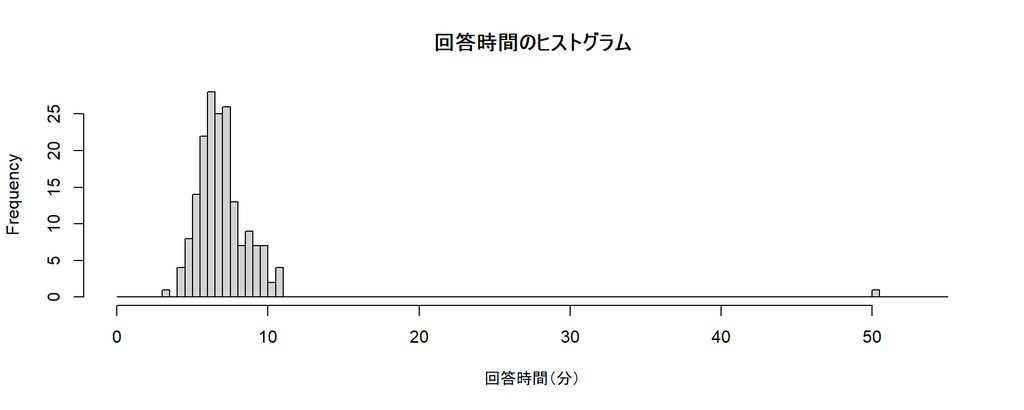

```r
dat_cwm %>%
  pull(duration) %>%
  hist(breaks = seq(0, 55, by = 0.5),
       main = "回答時間のヒストグラム",
       xlab = "回答時間（分）")
```

- 極端に短い回答はないが、一人50分もかかっている回答者がいる
- 理由はわからないが以下のような可能性も考えられる。
  - 一度回答を中断して、後で再開した
  - 回答完了後、同一内容を再送信してしまった
- 約10分で回答できるはずの調査なので、**30分以上かかっている回答者は除外**しましょう。

## 分析対象者の決定

今回は、理解度チェックと回答時間の両方で条件を満たす参加者を分析対象とします。

```r
dat_cwm %>%
  filter(pass_checks & duration < 30) %>%
  nrow()
```

```
[1] 170
```

**重要**

除外基準は、方法セクションに明確に書く。

## 演習４：分析対象者数を集計する

以下の文章を完成させるために、**回答者全体**と**分析対象者**の人数と性別内訳を集計しましょう。また、心理学実験履修者についても同様に集計しましょう。 `filter()`, `pull()`, `table()`を使うと便利です。

参加者は大学生XX名（男性XX名，女性XX名，その他・無回答XX名）であった。理解度チェックの基準を満たさなかったXX名を除外し，最終的な分析対象はXX名（男性XX名，女性XX名，その他・無回答XX名）とした。なお，心理学実験履修者XX名（男性XX名，女性XX名，その他・無回答XX名）のうち，基準を満たした分析対象者はXX名（男性XX名，女性XX名，その他・無回答XX名）であった。

**ノート**

性別などの属性は、報告に必要な範囲でまとめます。今回は人数が少ないカテゴリは「その他・無回答」としてまとめましょう。

## 分析対象者数の集計結果（演習４ 回答例）

```r
# 回答者全体の性別内訳
dat_cwm %>%
  pull(gender) %>%
  table()
```

```
.
女性 男性
 115   63
```

```r
# 分析対象者の性別内訳
dat_cwm %>%
  filter(pass_checks & duration < 30)  %>%
  pull(gender) %>%
  table()
```

```
.
女性 男性
 110   60
```

```r
# 心理学実験履修者
dat_cwm_jikken <- dat_cwm %>%
  filter(group == 1)

dat_cwm_jikken %>%
  pull(gender) %>%
  table()
```

```
.
女性 男性
  24   14
```

```r
dat_cwm_jikken %>%
  filter(pass_checks & duration < 30) %>%
  pull(gender) %>%
  table()
```

```
.
女性 男性
  24   12
```

# クロスワイズモデルによる推定

(全体データ)

## 分析用データを成形する

分析対象者のみにして、列名も変える (後で直接質問法と比較するため)

```r
dat_cwm_anlys <- dat_cwm %>%
  filter(pass_checks & duration < 30) %>%
  rename(
    item1 = CWM_1,
    item2 = CWM_2,
    item3 = CWM_3,
    item4 = CWM_4,
    item5 = CWM_5,
    item6 = CWM_6,
    item7 = CWM_7,
    item8 = CWM_8
  )
```

マスク項目の既知確率も用意する

```r
p_z <- 0.0986
```

## 推定方法

本当は`RRreg`という間接質問法用の推定パッケージがあります。  
ただ、これは、信頼区間の算出を自動でやってくれません。  
なので今回は、自作の関数で推定を行います。

## クロスワイズモデル推定のための自作関数

```r
crosswise_with_CI <- function(col, p=1, type=c("crosswise", "binom")){
  type = match.arg(type)
  if(type == "binom") p <- 1

  y <- sum(col)
  n <- length(col)

  loglik <- function(pi, y, n, p){
    lambda <- pi*p + (1-pi)*(1-p)
    if(y == 0){
      (n-y)*log(1-lambda)
    }else if(y == n){
      y*log(lambda)
    }else{
      y*log(lambda) + (n-y)*log(1-lambda)
    }
  }

  lambda_hat <- y/n
  pi_hat <- (lambda_hat + p - 1) / (2 * p - 1)
  pi_hat <- max(min(1, pi_hat), 0)
  se = sqrt((lambda_hat * (1-lambda_hat)) / ((n-1) * (2*p-1)^2))

  cutoff <-
    loglik(pi_hat,y,n,p) -
    qchisq(.95,1)/2

  f <- function(pi){
    loglik(pi,y,n,p)-cutoff
  }

  lower <- if(f(0) >= 0) 0 else
    uniroot(f, c(0,pi_hat))$root

  upper <- if(f(1) >= 0) 1 else
    uniroot(f, c(pi_hat,1))$root

  c("Estimate"=pi_hat, "StdErr" = se, "ci_low"=lower, "ci_high"=upper)
}
```

この関数は授業用に用意したものです。関数の中身を完全に理解する必要はありません。出力される推定値・標準誤差・95%尤度比信頼区間を読み取れることが重要です。

## 自作関数の入出力

### 入力

- `col`: 推定したい項目の回答ベクトル
  - クロスワイズモデルでは  
    「同じ」= 1、「異なる」= 0
  - 直接質問法では  
    「該当する」= 1、「該当しない」= 0
- `p`: マスク項目に該当する既知確率
  - 今回は`0.0986`
  - 直接質問法では使わない
- `type`: 推定方法
  - `"crosswise"`: クロスワイズモデルとして推定
  - `"binom"`: 通常の二項比率として推定

### 出力

返り値は、次の4つの値を持つベクトルです。

- `Estimate`: 推定された該当率
- `StdErr`: 推定値の標準誤差
- `ci_low`: 95%信頼区間の下限
- `ci_high`: 95%信頼区間の上限

**ノート**

この関数は、授業用に必要な出力だけを取り出すための簡略版です。関数の中では、観測された「同じ」の割合から該当率を推定し、その推定値の不確実性を標準誤差と尤度比信頼区間で表しています。

## 関数の使い方を確認する

まずは、1項目だけで実行して、入力と出力の対応を確認します。

```r
crosswise_with_CI(
  col = dat_cwm_anlys$item1,
  p = p_z,
  type = "crosswise"
)
```

```
  Estimate     StdErr     ci_low    ci_high
0.47069082 0.04785616 0.37813823 0.56410954
```

**ノート**

ここでは `dat_cwm_anlys$item1` という1列だけを関数に入れています。複数項目をまとめて推定するときは、このあと出てくる `lapply()` を使って同じ処理を各項目に繰り返します。

推定値とSEが`RRreg::RRuni()`の結果が整合するかも確認済みです

```r
RRreg::RRuni(item1, model = "Crosswise", p = p_z, data = dat_cwm_anlys)
```

```
RR model:
Crosswise Model with p = 0.0986

Estimate of pi:
0.470691 (0.047856)
```

## Wald型信頼区間

`RRreg`パッケージでも標準誤差は算出されるので、 標本統計量が近似的に正規分布に従うことを利用して **Wald型の95%信頼区間**：

$$\hat\pi \pm 1.96 \times SE(\hat\pi)$$
という信頼区間を算出することはできます。

```r
fit6 <- RRreg::RRuni(item6, model = "Crosswise", p = p_z, data = dat_cwm_anlys)
fit6
```

```
RR model:
Crosswise Model with p = 0.0986

Estimate of pi:
0.016398 (0.03019)
```

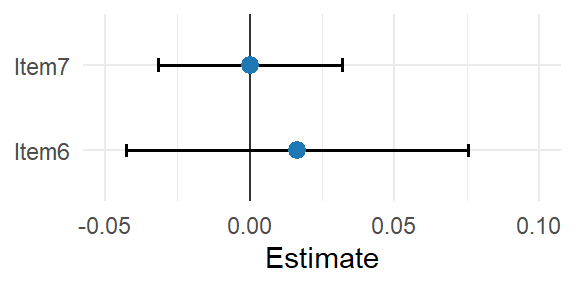

ただし、以下のような弱点があります。

推定値と標準誤差だけで信頼区間を作ると、次のような問題が出る。

- 下限が0未満になる、上限が1を超える
- MLEが0または1に近いと、標準誤差による近似が不安定になる
- SEが0になって、信頼区間が1点になる

**区間として解釈しにくくなる**

推定率は確率なので、最終的な区間は0から1の範囲で解釈できる形にしたい。

## 尤度比信頼区間

実は、標本サイズが十分大きいと$\chi^2$分布に従う、尤度比統計量というものがあります。
$$2\{\ell(\hat\pi)-\ell(\pi)\}
\overset{approx}{\sim}
\chi^2_1$$

これを利用した**尤度比検定**という検定手法があります。

これを反転させると、**尤度比信頼区間**（Likelihood Ratio Confidence Interval）というものが算出できます。

- 利点
  - 非対称な区間でも構成できる
  - 境界付近で不自然な区間になりづらい
  - パラメータ空間と矛盾しない

**ノート**

尤度比検定は多くの統計的検定の背後にある統一的な考え方の一つである

尤度比検定は特殊な検定ではなく、最尤推定に基づく統計モデルにおける非常に基本的な検定原理である。t検定、分散分析、回帰分析で用いられる検定とも密接な関係があり、多くの場合同じ結論を与える。

## 全項目で推定する

```r
fit_cwm_tbl <-
  dat_cwm_anlys %>%
  select(starts_with("item")) %>%
  lapply(crosswise_with_CI, p = p_z, type = "crosswise") %>%
  bind_rows() %>%
  mutate(
    item = paste0("Item", row_number()),
    method = "crosswise"
  )
```

```r
fit_cwm_tbl
```

```
# A tibble: 8 × 6
  Estimate StdErr  ci_low ci_high item  method
     <dbl>  <dbl>   <dbl>   <dbl> <chr> <chr>
1   0.471  0.0479 0.378    0.564  Item1 crosswise
2   0.200  0.0420 0.122    0.286  Item2 crosswise
3   0.258  0.0442 0.176    0.348  Item3 crosswise
4   0.0750 0.0350 0.0132   0.150  Item4 crosswise
5   0.0677 0.0345 0.00697  0.141  Item5 crosswise
6   0.0164 0.0302 0        0.0825 Item6 crosswise
7   0      0.0162 0        0.0175 Item7 crosswise
8   0.112  0.0375 0.0446   0.190  Item8 crosswise
```

### 流れ （ぜひ一行ずつ実行して、試してみてください）

1. `dat_cwm_anlys`  
   分析対象者だけに絞ったデータを使う。
2. `select(starts_with("item"))`  
   `item` から始まる列だけを取り出す。  
   ここでは，8項目の回答列をまとめて選んでいる。
3. `lapply(...)`  
   各項目に対して，同じ推定処理をくり返す。  
   ここでは，各項目に `crosswise_with_CI()` を適用している。
4. `bind_rows()`  
   8項目分の推定結果を，1つの表にまとめる。
5. `mutate(...)`  
   項目名と推定方法の名前を追加する。

## 演習５：プロットを出力してみましょう

`ggplot2`をつかって `fit_cwm_tbl`の推定結果から、推定値と95%尤度比信頼区間をプロットしてみましょう。 完成目標は以下の通りです。

```r
plot_crosswise
```

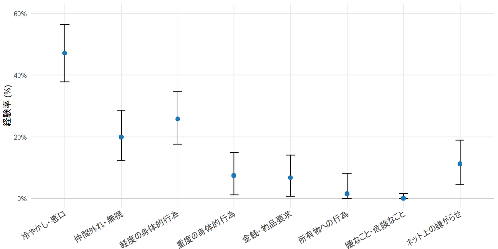

Figure 1 クロスワイズモデルによる各項目の推定値。点は推定値を，エラーバーは95%尤度比信頼区間を示す。

# クロスワイズモデルによる推定

(『心理学実験』でのデータ)

## 直接質問法との比較

- 間接質問法の推定結果と直接質問法の推定結果を比較します
- ただし，今回の比較はランダム割り当てによる比較ではないため，両手法の差を質問法そのものの効果として解釈することはできません。
- 具体的な課題
  - 標本の偏りから推定にバイアスが生じる可能性
  - 標本サイズが小さいため、推定精度が不十分
  - 順序効果が生じる可能性

ここでは，あくまで記述的・補助的な比較として確認する。

```r
data_direct <- read.csv(file.path("002input", "01_data_direct.csv")) %>%
  as_tibble()
```

## 自作関数での推定

```r
dat_cwm_anlys_jikken <- dat_cwm_anlys %>%
  filter(group == 1)

fit_cwm_jikken_tbl <-
  dat_cwm_anlys_jikken %>%
  select(starts_with("item")) %>%
  lapply(crosswise_with_CI, p = p_z, type = "crosswise") %>%
  bind_rows() %>%
  mutate(
    item = paste0("Item", row_number()),
    method = "crosswise"
  )

fit_direct_jikken_tbl <-
  data_direct %>%
  select(starts_with("item")) %>%
  lapply(crosswise_with_CI, type ="binom") %>%
  bind_rows() %>%
  mutate(
    item = paste0("Item", row_number()),
    method = "direct"
  )

fit_jikken_tbl <-
  bind_rows(
    fit_direct_jikken_tbl,
    fit_cwm_jikken_tbl
  )
```

```r
fit_jikken_tbl
```

```
# A tibble: 16 × 6
   Estimate StdErr  ci_low ci_high item  method
      <dbl>  <dbl>   <dbl>   <dbl> <chr> <chr>
 1   0.447  0.0817 0.297    0.605  Item1 direct
 2   0.0789 0.0443 0.0202   0.192  Item2 direct
 3   0.132  0.0556 0.0493   0.262  Item3 direct
 4   0      0      0        0.0493 Item4 direct
 5   0.0263 0.0263 0.00152  0.111  Item5 direct
 6   0      0      0        0.0493 Item6 direct
 7   0.0263 0.0263 0.00152  0.111  Item7 direct
 8   0.0526 0.0367 0.00895  0.154  Item8 direct
 9   0.396  0.104  0.208    0.599  Item1 crosswise
10   0.258  0.0970 0.0915   0.457  Item2 crosswise
11   0.189  0.0912 0.0377   0.382  Item3 crosswise
12   0.119  0.0833 0        0.304  Item4 crosswise
13   0.0848 0.0785 0        0.262  Item5 crosswise
14   0.0502 0.0728 0        0.220  Item6 crosswise
15   0      0.0482 0        0.0975 Item7 crosswise
16   0.0848 0.0785 0        0.262  Item8 crosswise
```

## 演習６：プロットを出力してみましょう その２

`ggplot2`をつかって `fit_jikken_tbl`の推定結果から、二つの質問法での推定値と95%尤度比信頼区間をプロットしてみましょう。 完成目標は以下の通りです。

```r
plot_jikken
```

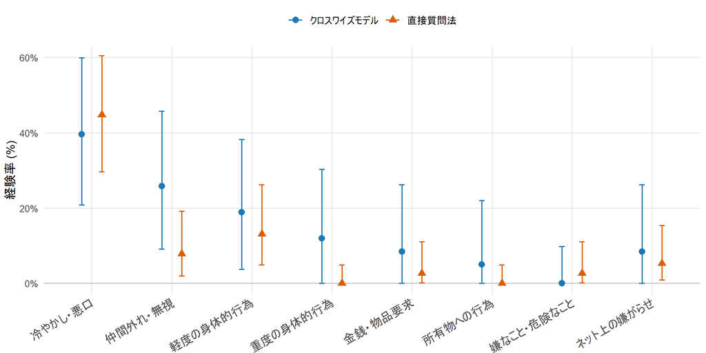

Figure 1 心理学実験履修者におけるクロスワイズモデルと直接質問法による各項目の推定値。点は推定値を，エラーバーは95%尤度比信頼区間を示す。

## Wald型信頼区間と尤度比信頼区間の比較

### Wald型信頼区間

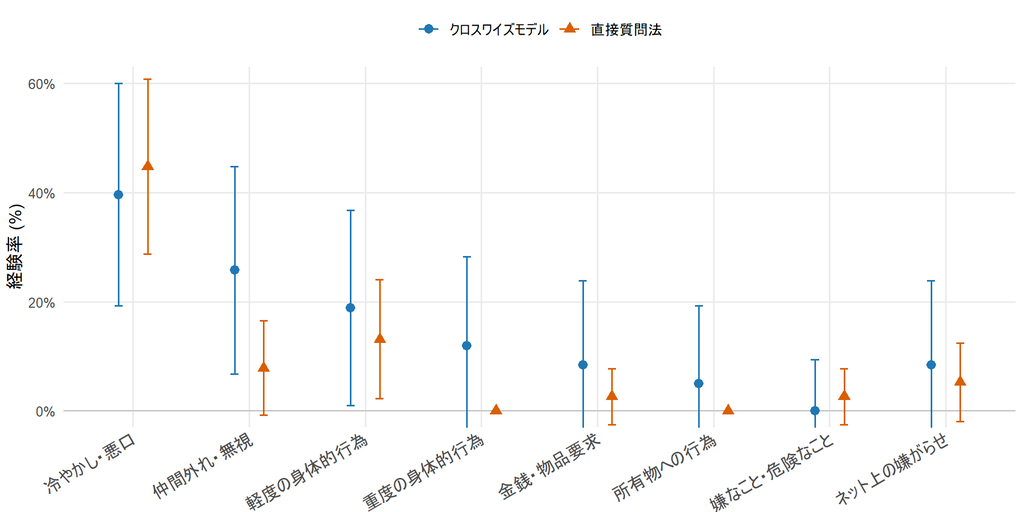

```r
plot_jikken_wald
```

### 尤度比信頼区間

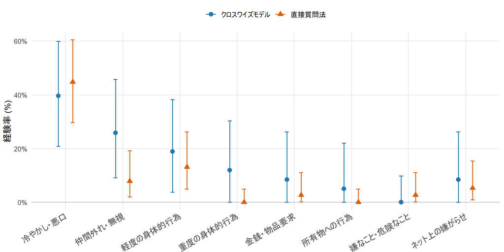

```r
plot_jikken
```

尤度比信頼区間の方が、割合の推定として解釈しやすい結果となってますね。

## 直接質問法と間接質問法の比較に関する注意点

今回の直接質問法は、クロスワイズモデルの推定値を解釈するための補助的な指標である。

### 比較上の限界

1. サンプルサイズが小さいため，推定精度に限界がある。
2. 心理学実験履修者のみを対象としているため，結果の一般化には注意が必要である。
3. 同一参加者が両質問法に回答しているため，順序効果やキャリーオーバー効果を排除できない。
4. 無作為割り当てではないため，推定値の差を質問法自体の効果として解釈することはできない。

## 表の作成

今回は表も作成してもらいます。情報としてはざっくりこんな感じのイメージかなと思います。  
（以下はRで作成した簡易的な表であり，レポートに掲載する際には，表記，桁数，項目名，罫線，表題などを整える必要があります。）

| item | Estimate | StdErr | CI |
| --- | --- | --- | --- |
| Item1 | 47.1% | 4.8% | [37.8%, 56.4%] |
| Item2 | 20.0% | 4.2% | [12.2%, 28.6%] |
| Item3 | 25.8% | 4.4% | [17.6%, 34.8%] |
| Item4 | 7.5% | 3.5% | [1.3%, 15.0%] |
| Item5 | 6.8% | 3.4% | [0.7%, 14.1%] |
| Item6 | 1.6% | 3.0% | [0.0%, 8.3%] |
| Item7 | 0.0% | 1.6% | [0.0%, 1.7%] |
| Item8 | 11.2% | 3.7% | [4.5%, 19.0%] |

| item | method | Estimate | StdErr | CI |
| --- | --- | --- | --- | --- |
| Item1 | crosswise | 39.6% | 10.4% | [20.8%, 59.9%] |
| Item1 | direct | 44.7% | 8.2% | [29.7%, 60.5%] |
| Item2 | crosswise | 25.8% | 9.7% | [9.2%, 45.7%] |
| Item2 | direct | 7.9% | 4.4% | [2.0%, 19.2%] |
| Item3 | crosswise | 18.9% | 9.1% | [3.8%, 38.2%] |
| Item3 | direct | 13.2% | 5.6% | [4.9%, 26.2%] |
| Item4 | crosswise | 11.9% | 8.3% | [0.0%, 30.4%] |
| Item4 | direct | 0.0% | 0.0% | [0.0%, 4.9%] |
| Item5 | crosswise | 8.5% | 7.8% | [0.0%, 26.2%] |
| Item5 | direct | 2.6% | 2.6% | [0.2%, 11.1%] |
| Item6 | crosswise | 5.0% | 7.3% | [0.0%, 22.0%] |
| Item6 | direct | 0.0% | 0.0% | [0.0%, 4.9%] |
| Item7 | crosswise | 0.0% | 4.8% | [0.0%, 9.8%] |
| Item7 | direct | 2.6% | 2.6% | [0.2%, 11.1%] |
| Item8 | crosswise | 8.5% | 7.8% | [0.0%, 26.2%] |
| Item8 | direct | 5.3% | 3.7% | [0.9%, 15.4%] |

# レポートの書き方

## 序論に書くこと

- 第一回の資料やテンプレートを確認しながら、記述してください。
- **タイトルは研究内容を反映して、独自につけること**
- 今回の研究内容・方法に自然と繋がるように、序論を作成しましょう。
  - 本来、研究では、調べたい・明らかにしたいことが先にあって、  
    その後に研究内容・方法が自然と決まります。
  - ただし、今回は研究内容・方法が先行しているので、  
    これに論理的に繋がるような研究動機を作ってください。

### 重要ポイント

- 論理的に、推測の余地なく、わかりやすく書きましょう
- 研究の貢献を明確に主張することは、研究者側の義務です。
  - 読者が一読してわかるように書きます。
- 松井先生の書き方とかめちゃくちゃ参考になりますね。

## 方法セクションに書くこと

- 1. **調査参加者**
  - 対象者について
  - サンプルサイズ設計について
- 2. **調査手続き**
  - 実施方法（Google Form）
  - 具体的な流れ
- 3. **測定項目**
  - いじめ加害経験
    - クロスワイズモデルの詳細
  - 理解度チェック
  - デモグラフィック項目
- 4. **分析方法**
  - クロスワイズモデルの推定方法等

## 結果セクションに書くこと

**ノート**

結果はあくまで客観的な数値・結果のみを報告すること。解釈は考察で行う

## 図表の作成方法

- 図表の注意点
  - 番号を付ける：Table 1
  - タイトルを付ける：いじめ加害経験の推定割合
  - 本文で必ず言及する：Table 1に示すように
  - 図表だけで意味がわかるようにする
  - 本文でも主要な結果を説明する
- 表の注意点
  - 単位を明記する：割合なら「%」
  - 小数点以下の桁数をそろえる
  - 縦罫線は基本は使わない
  - 横罫線も最低限にする
- 図の注意点
  - エラーバーが何を表すか明記する
  - 例：「エラーバーは95%信頼区間を示す」
  - 縦軸の範囲を不自然に狭めない
    - 割合なら原則として0を含める
  - 色だけで条件を区別しない
    - 色覚多様性に配慮する＆白黒印刷でもみえるように

## 考察セクションに書くこと

考察では、単に数値を繰り返すのではなく、結果の意味を考える。

- 項目間（=行動間）での結果の違い
- 直接質問法よりCWM推定率が高かったか否か
- センシティブ項目で過少報告が起こっていた可能性
- 理解度確認を行ったことの意味
- サンプルサイズが推定精度に与える影響
- 今回の研究の限界

## クロスワイズモデルの限界は?

間接質問法の弱点

- 理解が難しいこと
  - 手続きを正確に実施する必要がある
  - その手続きによって匿名性が守られていることを信じる必要がある
  - 理解していてもなお、回答者が不安を感じることもある (Hoffmann et al. 2017)
- 推定精度の低下
  - 一般に直接質問法に比べて標準誤差が大きくなりやすく，信頼区間も広くなりやすい
- マスク項目の該当率
  - 約0.1だったが、これは小さすぎたかもしれない
    - 回答者によってはプライバシー保護の感覚が弱くなる可能性がある。
  - 一方で、0.5に近いと、推定値の分散が大きくなる (発散する)。

## 引用文献

- **論理・主張上、必要な文献**はちゃんと引用しましょう
  - 文献検索の補助としてLLMを使ってもよいですが、最終的には**必ず原典**を確認してください。
- もちろん授業中に引用した文献でもいいです。
  - ただし、スライドの引用文献のスタイルは『執筆の手引き』スタイルではないです。
  - ちゃんと『手引き』スタイルで作成してください。

## レポートの書き方（その他）

- この資料やテンプレートに書いていないことでも、これまでのテーマ(知覚運動学習、錯視など)で学んだことは、すべて反映させてください
  - すべてのルールや作法を毎テーマ解説してもキリないですよね
- 論文を書く上で困ったら（困らなくても）、**とにかく出版済みの査読論文を完璧にまねてください**。
  - 明文化されていない、暗黙のルールみたいなのが実は結構あります。
    - そこから外れた論文は、慣れた読者には、研究論文として不自然に見えることがあります。
    - 出版済みの査読論文を参考にして、構成・図表・表現の作法を学んでください。ただし、文章をそのまま写すのではなく、自分の研究内容に合わせて書いてください。

## 今回まとめ

1. センシティブ項目では、直接質問だけでは実態を捉えにくいことがある
2. クロスワイズモデルでは、個人の回答を保護しながら集団の該当率を推定できる
3. ただし、回答者が手続きを理解していることが重要である
4. 推定値には不確実性があるため、標準誤差や信頼区間も報告する
5. 結果はグラフだけでなく、表として整理することも重要である

## レポート提出

### レポートの提出期限

**7/6(月) 23:59 JST**

- CLEで提出
- スライドの内容やテンプレートに基づいて作成してください。
- 質問があれば、fukushima.hus@osaka-u.ac.jpまで

## References

Tight, M. (2023). Bullying in higher education: an endemic problem? *Tertiary Education and Management*, *29*(2), 123–137.

Yu, J.-W., Tian, G.-L., & Tang, M.-L. (2008). Two New Models for Survey Sampling with Sensitive Characteristic: Design and Analysis. *Metrika*, *67*, 251–263. https://doi.org/10.1007/s00184-007-0131-x

伊藤美奈子. (2017). いじめる・いじめられる経験の背景要因に関する基礎的研究: 自尊感情に着目して. *教育心理学研究*, *65*(1), 26–36. https://doi.org/10.5926/jjep.65.26

小林哲郎・三浦麻子. (2024). リスト実験を用いたセンシティビティバイアスの検出における直接質問形式の影響. *社会心理学研究*, *40*(1), 18–27. https://doi.org/10.14966/jssp.2023-004